# Four Phillies

Jim Albert

3/22/2019

#### Introduction

Here is a demo of some of the graphics functions available in the CalledStrike package.

#### Scraping data for four players

Suppose I’m interested in exploring various batting rates for four 2018 Phillies, Andrew McCutchen, Maikel Franco, Bryce Harper and Jean Segura.

I put the names in a vector and use a collect_many_players() function that will scrape the data from Baseball Savant and create a list of data frames.

#### Some filled contour graphs

All of the following graphs are produced by a single function compare_contour() that constructs a filled contour graph using one of eight different plot types.

First, the batter has to decide whether to swing at the pitch. Here I show a filled contour graph of the rate of swinging. McCutchen has a much smaller “likely swing” region than Franco.

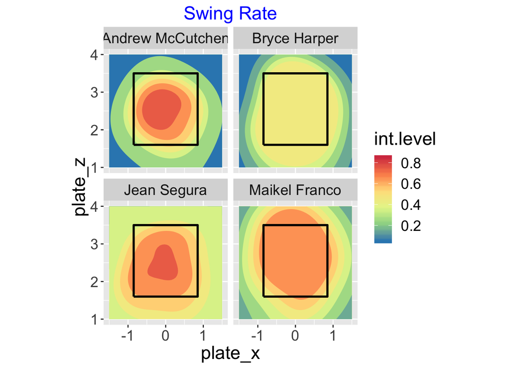

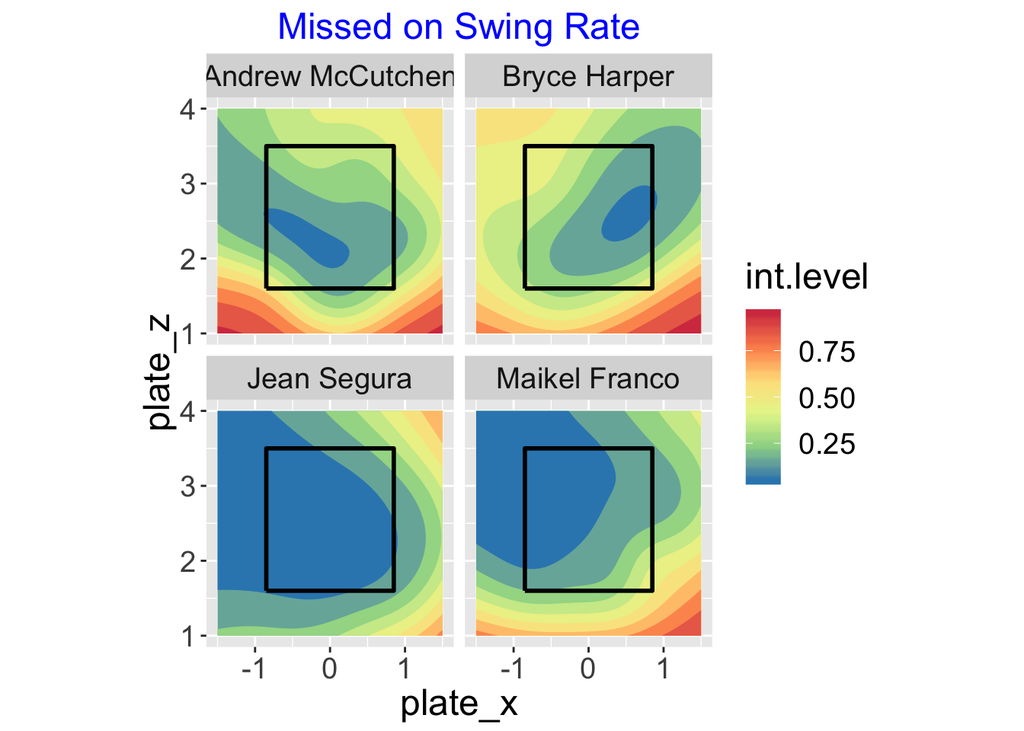

#### Statcast measurements off the bat

If the batter puts the ball in play, a number of measurements are made off of the bat. Here we show filled contours of the launch speed. Of these four hitters, Harper tends to hit the ball the hardest.

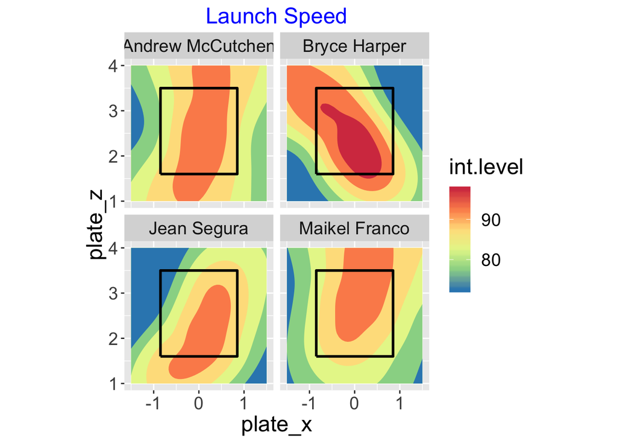

Here we look at the launch angle. Generally balls high in the zone are hit at a high launch angle.

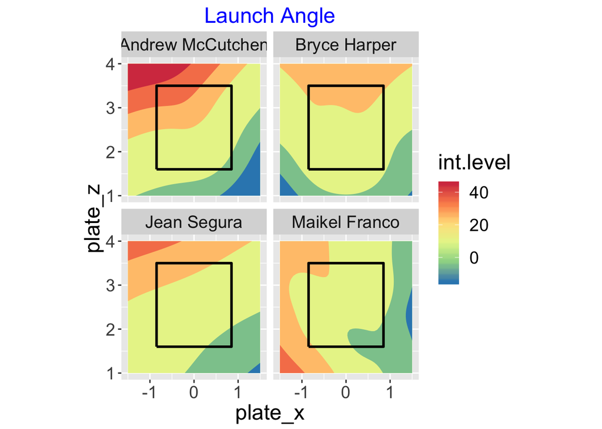

Here we explore the spray angle. Harper tends to be a strong pull hitter – inside pitches are hit at a positive spray angle (right side of the field).

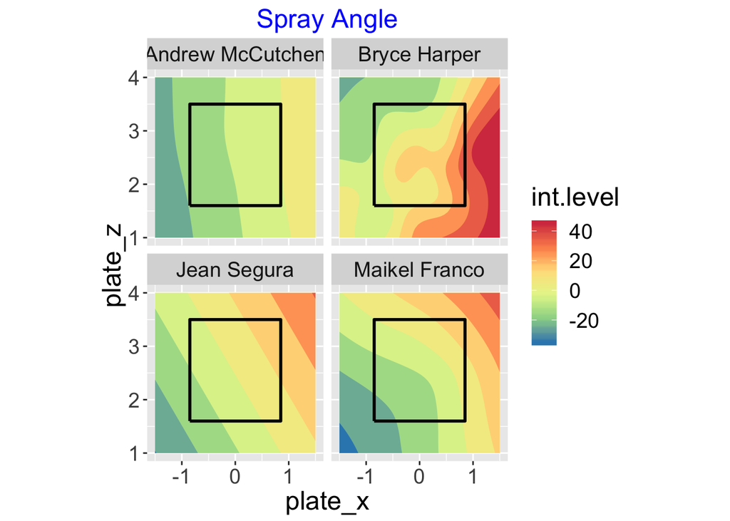

#### In play rates

Last, we consider desirable outcomes on balls in play. Here are filled contours of the player’s in-play hit rate.

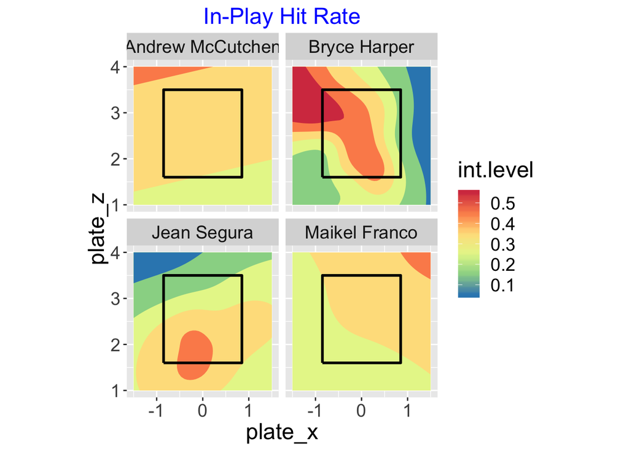

Here are filled contours of the player’s in-play home run rate.

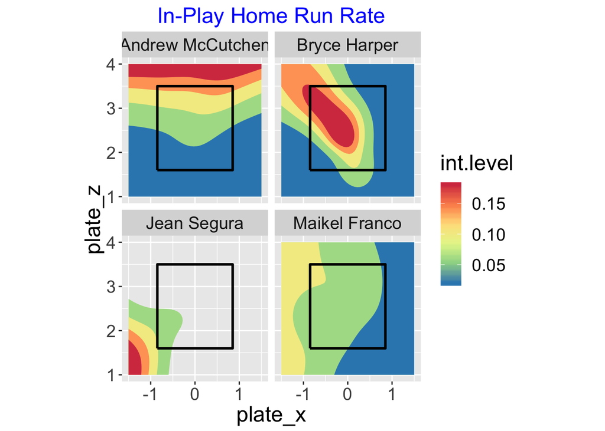